# 2.3. Advanced Data Structures

Module M-227-04: Programming for Data Analytics

Instructor: prof. Dmitry Pavlyuk

## Advanced Data Structures

- **Graph** is a data structure, storing a set of objects (vertices) in which some pairs of the objects are in some sense "related" (connected with edges.
- **Tree** is an undirected graph in which any two vertices are connected by exactly one path
- **Forest** is a disjoint union of trees

Implemented in Python libraries

## Graph

- **Graph** is a data structure, storing a set of objects (vertices) in which some pairs of the objects are in some sense "related" (connected with edges.

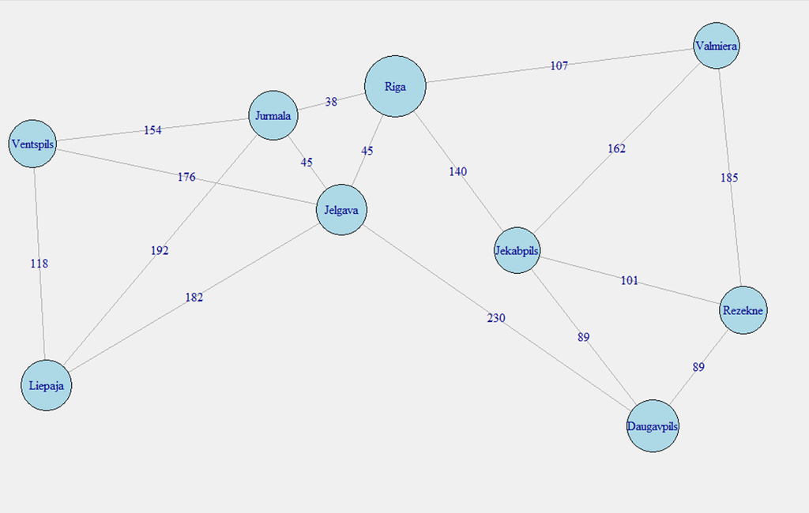

## Graph: important types

- Directed vs. Undirected
- Weighted vs. Unweighted
- Connected vs. Disconnected
- Planar vs. Non-planar

## Graph: important problems

- Shortest path
- Connectivity
- Travelling salesman
- Minimum spanning tree
- Maximum network flow

## Tree

- **Tree** is an undirected graph in which any two vertices are connected by exactly one path

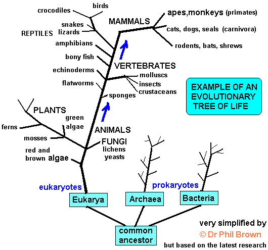

## Tree: important applications

- Storing hierachies (biological, organisational, etc.)
- Decision trees in Machine Learning
- Fast search and insert of data (e.g., database indexing)

## Forest

- **Forest** is a disjoint union of trees

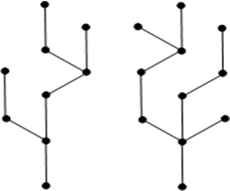

## Forest: important application

- Random forest in machine learning is an ensemble learning method for classification, regression and other tasks that operates by constructing a multitude of decision trees at training time.

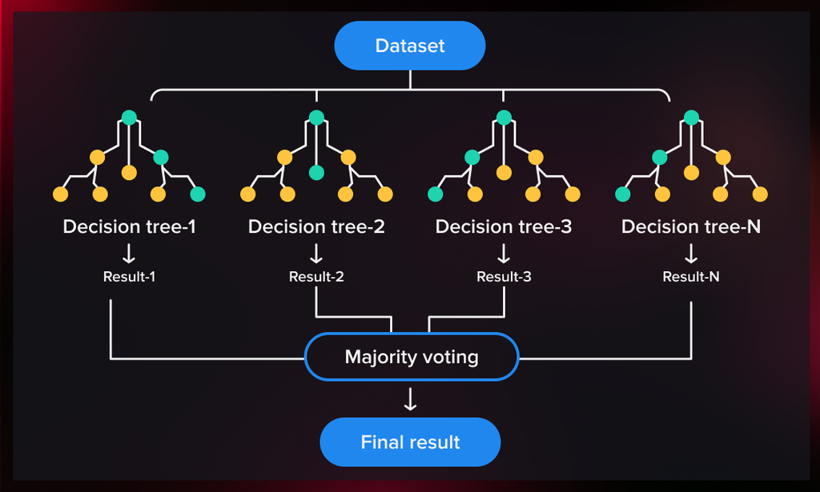

## Useful Libraries

- **NetworkX** https://networkx.org/ - a Python library for the manipulation of the structure, dynamics, and functions of complex networks.
- **igraph** https://igraph.org/ - a C library for complex network analysis and graph theory, with emphasis on efficiency, portability and ease of use. Support C/C++, Python, R, Mathematica